# Statstic Inference Week4 Part 1

yangjpku@gmail.com

# Part 1:

## Overview

We investigate the exponential distribution in R and compare it with the Central Limit Theorem. The exponential distribution can be simulated in R with `rexp(n, lambda)` where lambda is the rate parameter. The mean of exponential distribution is `1/lambda` and the standard deviation is also `1/lambda`. Set `lambda = 0.2` for all of the simulations. You will investigate the distribution of averages of 40 exponentials. Note that you will need to do a thousand simulations.

To set lambda to be 0.2

```r
lambda<-0.2
```

## Simulation

1. Create the random data set from exponetial distributions

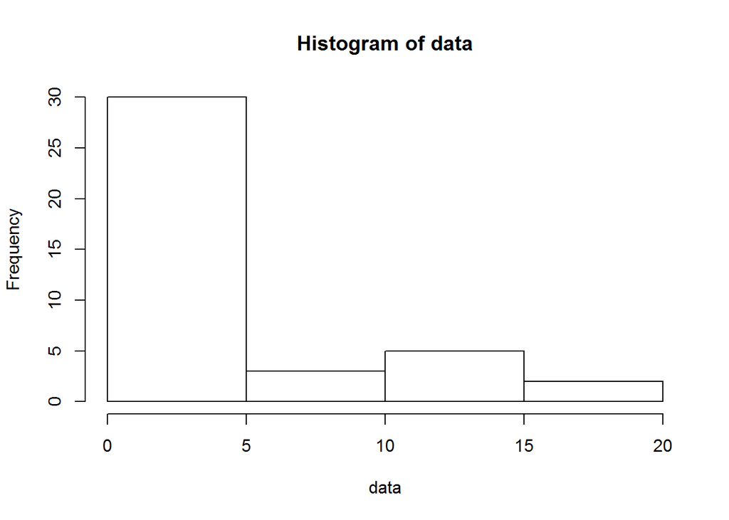

```r
n<-40
m<-1000
set.seed(1000)
data<-rexp(n, lambda)
#plot the histgram of the simulated dataset
hist(data)
```

2. Sample Mean versus Theoretical Mean:

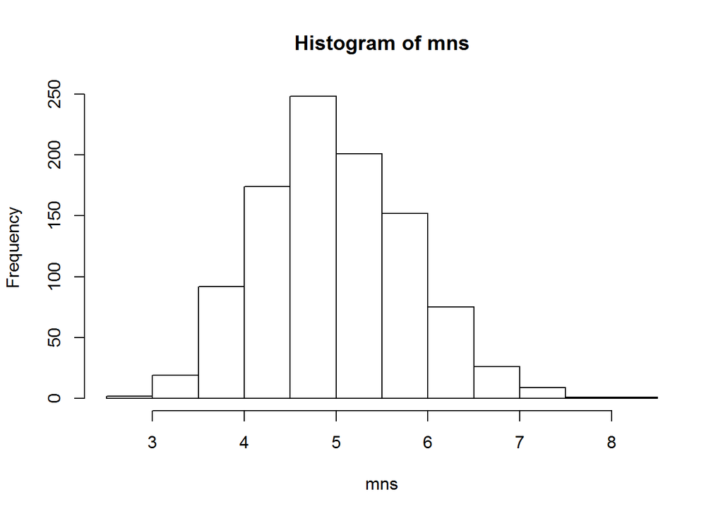

```r
#Generating the sample mean
mns = NULL
for (i in 1 : m) mns = c(mns, mean(data<-rexp(n, lambda) ))
hist(mns)
```

```r
print("The sample means")
```

```
## [1] "The sample means"
```

```r
sample_mean<-mean(mns)
print(round(sample_mean),4)
```

```
## [1] 5
```

```r
print("theoretical means should be")
```

```
## [1] "theoretical means should be"
```

```r
print(round(1/lambda),4)
```

```
## [1] 5
```

```r
print("the difference is ")
```

```
## [1] "the difference is "
```

```r
print(round(abs(sample_mean-1/lambda)),5)
```

```
## [1] 0
```

**Observations**: The difference is very small.

3. Sample Variance versus Theoretical Variance

```r
sample_var<-var(mns)
print("this is the sample variance")
```

```
## [1] "this is the sample variance"
```

```r
print(sample_var)
```

```
## [1] 0.6541206
```

```r
print("theoretical variance should be")
```

```
## [1] "theoretical variance should be"
```

```r
print(round((1/lambda)^2/n,4))
```

```
## [1] 0.625
```

```r
print("the difference is ")
```

```
## [1] "the difference is "
```

```r
print(round(abs(sample_var-1/lambda^2/n),5))
```

```
## [1] 0.02912
```

**Observations**: The difference is small.

4 Distribution:

According to the CLT, the averge should follow the normal distribution. Here’s the plot of the histgram again, it’s following the BELLshape

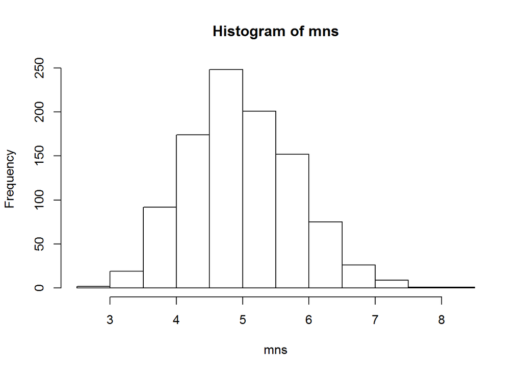

```r
hist(mns)
```

As suggested, we’ll focus on the difference between the distribution of a large collection of random exponentials and the distribution of a large collection of averages of 40 exponentials. Here we overlay the normal distribution from CTL

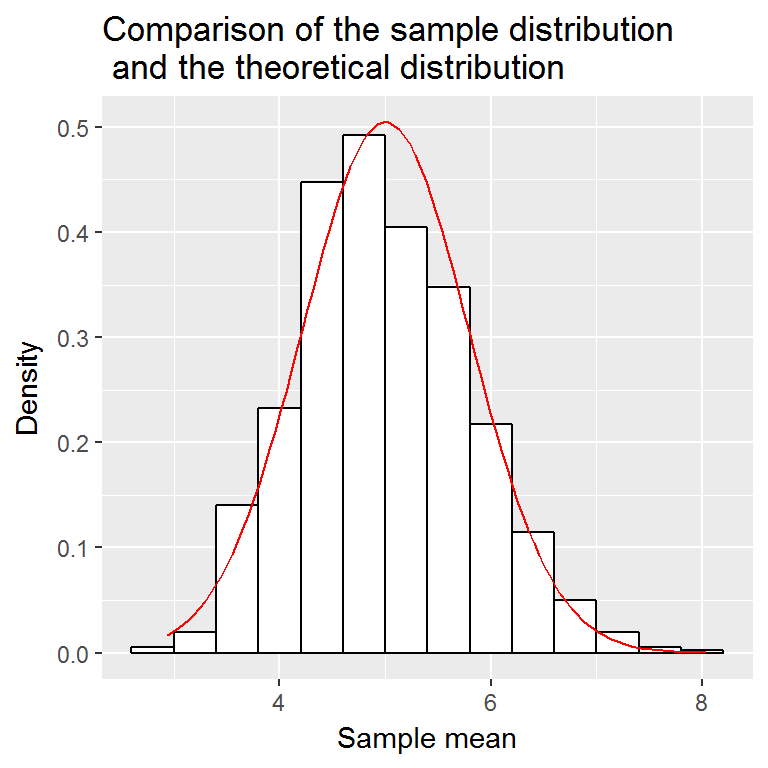

```r
library(ggplot2)
data <- as.data.frame(mns)
ggplot(data, aes(x = mns)) +
  geom_histogram(binwidth = 0.4, color = 'black', fill = 'white', aes(y = ..density..)) +
  stat_function(fun = dnorm, color = 'red',
                args = list(mean = 5, sd = sqrt(0.625))) +
  xlab('Sample mean') +
  ylab('Density') +
  ggtitle('Comparison of the sample distribution\n and the theoretical distribution')
```

**Conclusion**